# **I Linkin Park nelle Charts inglesi**

## Analisi della carriera e della rinascita della band

Fabio Urli

## **Introduzione, Motivazioni e Domande**

I **Linkin Park** sono una delle band più famose al mondo. In quanto mia band preferita, volevo dedicargli il progetto.

Con alle spalle due degli album più influenti degli anni 2000 e decine di singoli popolari, la loro carriera si è bruscamente fermata il **20 Luglio 2017** con la scomparsa del cantante **Chester Bennington**.

Dopo sette anni di stop, dal 2024 sono tornati con una nuova formazione ed un nuovo album.  
Inoltre hanno appena concluso un tour mondiale di due anni, praticamente tutto sold out.

Questo progetto è stato basato su **tre quesiti fondamentali**:

1. Come era vista la band prima della tragedia
2. Quanto la morte di Chester abbia influenzato le classifiche
3. Se il loro ritorno può essere considerato un successo

## **Descrizione dei Dati**

Il dataset utilizzato è stato interamente creato da me prendendo le informazioni da [www.officialcharts.com](https://www.officialcharts.com/), il sito delle classifiche musicali settimanali inglesi.

Nel dataset ho riportato:

1. La settimana di apparizione in classifica (da Gennaio 2001 a Luglio 2026)
2. Il titolo dell'album
3. La data di uscita
4. La categoria (se Studio, Remix, Live...)
5. La posizione in classifica (Top 100)

|  | settimana | album | uscita | categoria | posizione |
| --- | --- | --- | --- | --- | --- |
| 0 | 2001-01-13 | Hybrid Theory | 2000-10-24 | studio | 81 |
| 207 | 2002-08-10 | Reanimation | 2002-07-30 | remix | 3 |
| 292 | 2003-12-06 | Live In Texas | 2003-11-18 | live | 47 |
| 298 | 2004-12-11 | Collision Course | 2004-11-30 | ep | 38 |
| 457 | 2024-04-25 | Papercuts | 2024-04-12 | compilation | 4 |

## **Somma Complessiva delle Settimane (Fino al 20 Luglio 2017)**

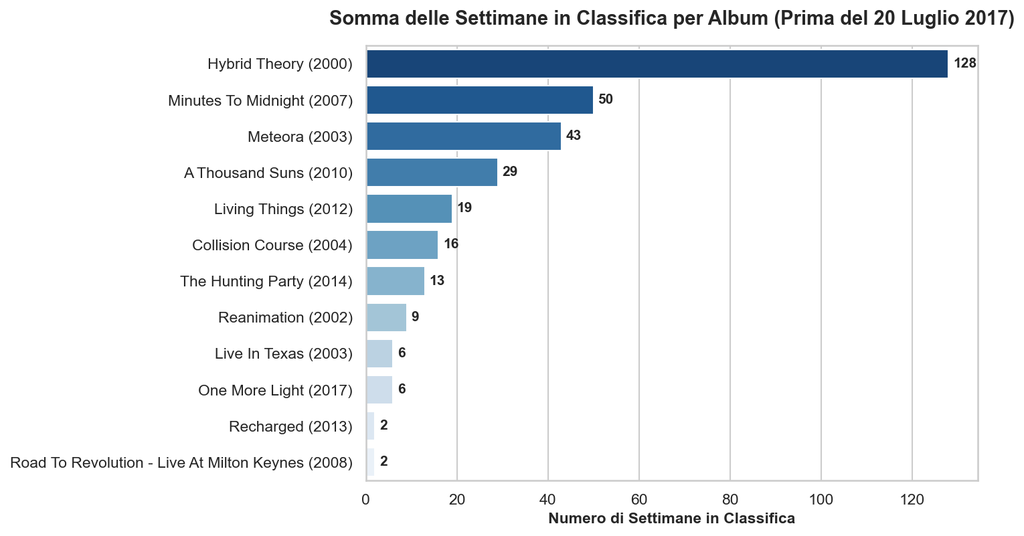

**Hybrid Theory** è così avanti perchè è uscito prima, no?

Non solo... E' l'unico album (assieme a **Meteora**) ad essere rientrato in classifica più volte a distanza di anni.

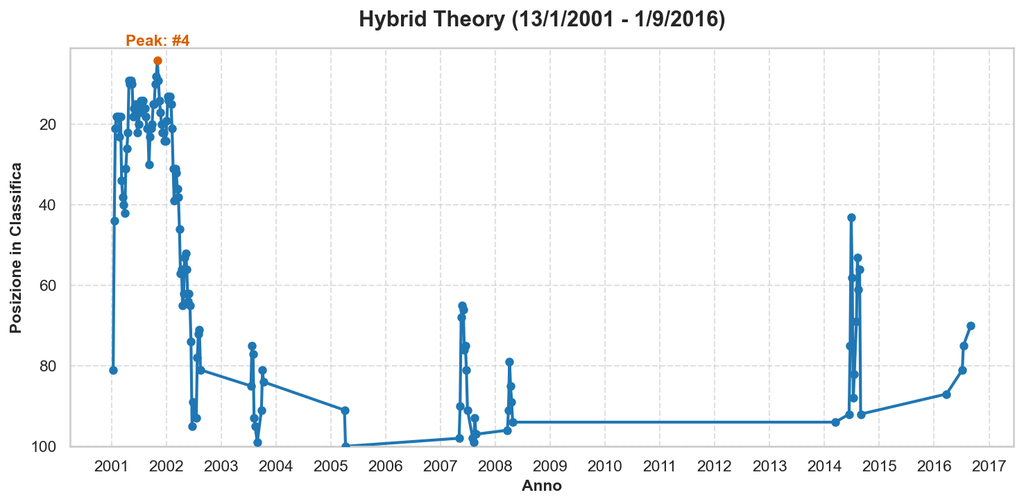

Apparte l'outlier di **Hybrid Theory**, gli album tendono ad essere in classifica per qualche mese dalla loro pubblicazione, per poi uscirne definitivamente (o quasi).

Vediamo **Meteora:**

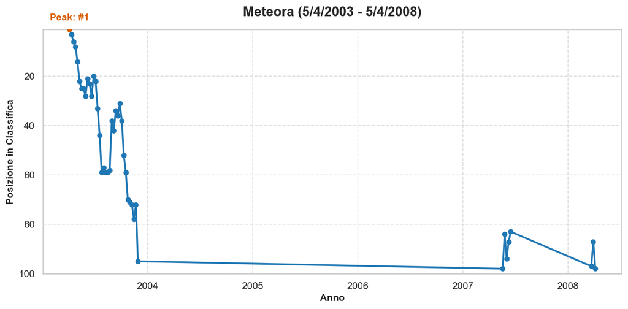

E Ora **Minutes To Midnight:**

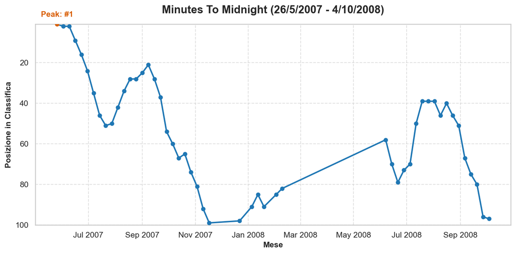

## **Quanto "il 20 Luglio" ha Impattato le Classifiche?**

[figure not shown]

## **E nel resto del 2017?**

[figure not shown]

## **I Linkin Park nel 2024**

Il 2024 è un anno fondamentale per la band e per questo progetto.  
Ad Aprile esce **Papercuts**, compilation di alcuni dei loro brani più famosi.  
A Settembre tornano con la nuova cantante **Emily Armstrong** ed a Novembre esce **From Zero**.

[figure not shown]

**Papercuts**

[figure not shown]

**From Zero**

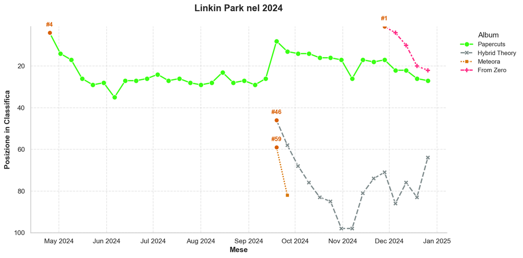

Notate come **Papercuts** sia tutte le settimane in classifica?  
Questo trend continuerà anche negli anni successivi!

## **I Linkin Park nel 2025**

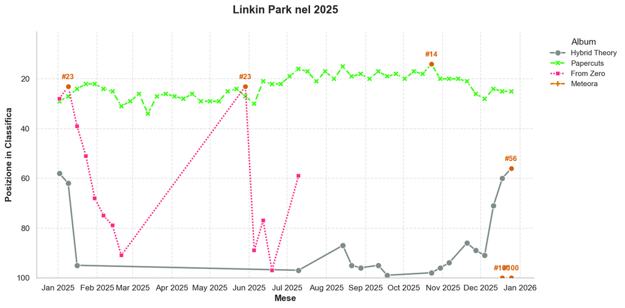

## **I Linkin Park nel 2026 (fino ad oggi)**

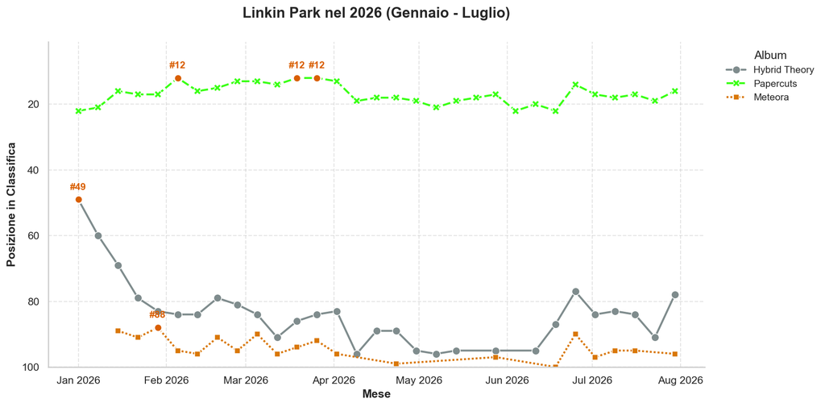

## **Somma Complessiva delle Settimane**

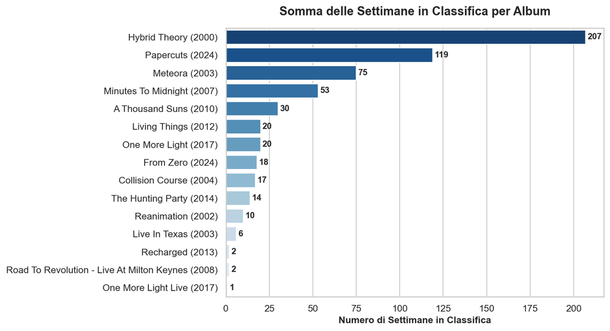

## **Conclusione: Parte 1**

Ora ritorniamo sui **tre quesiti iniziali:**

Nel corso degli anni l'andamento di un album in classifica prima e dopo il **20 Luglio 2017** è pressochè confermato.  
**Hybrid Theory** rimane al primo posto e solo **Meteora** e **One More Light** hanno scalato una o più posizioni.

La scomparsa di **Chester Bennington** ha ovviamente influenzato i risultati.  
Basta pensare alla massiccia presenza della band in classifica nella seconda metà del 2017.

## **Conclusione: Parte 2**

Questo è il probabile risultato del mercato musicale di oggi, dove si preferisce il singolo all'album.

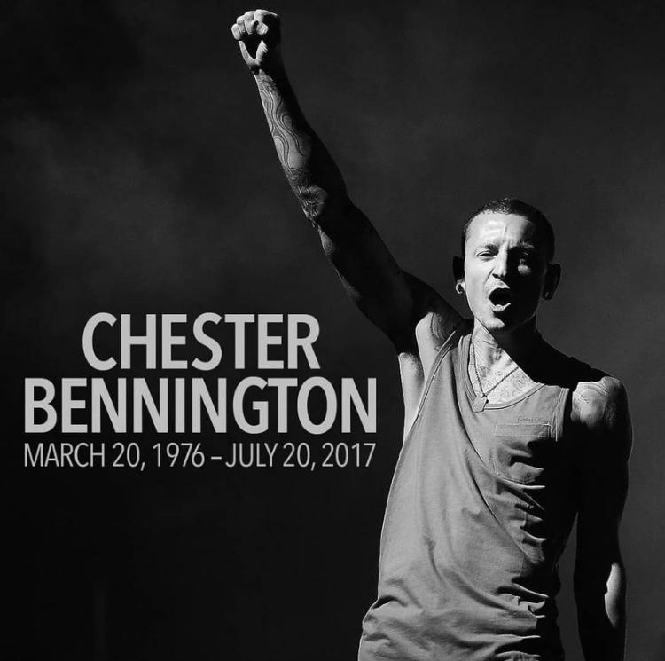